# Assignment2

## Project Description:

In this project, some optimization method will be studied such as Gradient, newton, quasi-newton etc. First the random data will be generated from a predefined linear regression model where $5\leq \beta_i \leq5$ and $i = 0,...,K$ with K = 120 independent variables $X = (X_1,X_2,...,X_K)$ and n = 1000 observations. In the project, it is seeked to adjust a multiple linear regression model to explain variable Y as a function of the other variables X, i.e.,($ Y = \beta 'X + \epsilon $) by using "Ridge Regression":

$$ \min_{\beta} ||y-X\beta||^2_2 + \rho ||\beta||^2_2$$

where $\rho$ is a parameter and consider it fixed to a given value $\rho = 1$

```python
# libraries
%matplotlib notebook
import numpy as np
from time import time
np.random.seed(100459259)

# number of preditors and number of observations
nvars = 120 ## K value
nsample = 1000
# beta between -5 and 5
beta = np.random.randint(-5,5,size=([nvars+1,1]))
## X model matrix
X0 = np.ones([nsample,1]) # the first column has all values equal to one for the coefficients of beta0
X1 = np.random.uniform(0,10,([nsample,nvars]))
X = np.concatenate([X0, X1],axis=1)
## Values for the normal errors
error = np.random.normal(0,1,(nsample,1))
## Values for the y's
Y = np.dot(X,beta) + error
```

### Visualizing some variables of the random data

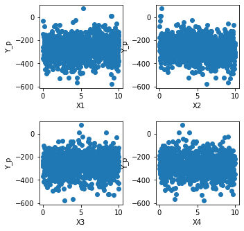

```python
import matplotlib.pyplot as plt
%matplotlib inline

Y_p = np.array(Y)

# Plot four of the variables
plt.figure(figsize=(5, 5))
plt.subplot(2, 2, 1)
plt.scatter(X[:,1], Y_p),plt.xlabel('X1'),plt.ylabel('Y_p')

plt.subplot(2, 2, 2)
plt.scatter(X[:,2], Y_p),plt.xlabel('X2'),plt.ylabel('Y_p')

plt.subplot(2, 2, 3)
plt.scatter(X[:,3], Y_p),plt.xlabel('X3'),plt.ylabel('Y_p')

plt.subplot(2, 2, 4)
plt.scatter(X[:,4], Y_p),plt.xlabel('X4'),plt.ylabel('Y_p')
plt.subplots_adjust(left=0.1, bottom=0.1, right=0.9, top=0.9, wspace = 0.4, hspace = 0.4)
plt.show()
```

## a) Estimating the value of the regression coefficients by implementing the analytical solution

For ridge regression, there exists an analytical solution. \ The exact solution is: $\beta^*=(X^T X + \rho I)^{-1}X^T y$

```python
from numpy.linalg import inv
from time import time

rho=1 # it represent the p value in the formula. I am assuming that it is 1.
time_start = time()
beta_ridge_exact=np.dot(np.dot(inv(np.dot((X.T),X)+rho*np.identity(nvars+1)),X.T),Y) ## I= identity matrix
time_end = time()

time_elapsed = (time_end - time_start)
# Print the results
print('Values of the (exact) ridge regression coefficients:')
for i in range(nvars+1):
    print('beta %3d %7.3f' %(i,beta_ridge_exact[i]))
print('Elapsed time = %8.5f' %(time_elapsed))
```

```
Values of the (exact) ridge regression coefficients:
beta   0  -0.988
beta   1   1.001
beta   2  -3.979
beta   3   0.987
beta   4  -2.994
beta   5   3.000
beta   6   1.983
beta   7   2.011
beta   8   2.995
beta   9  -5.005
beta  10   0.994
beta  11  -0.999
beta  12  -1.010
beta  13   0.008
beta  14   1.974
beta  15   1.990
beta  16   3.998
beta  17  -1.983
beta  18   3.982
beta  19  -3.999
beta  20  -3.008
beta  21   1.997
beta  22   0.980
beta  23   2.016
beta  24  -0.018
beta  25  -2.013
beta  26  -0.997
beta  27  -2.977
beta  28  -0.973
beta  29   2.999
beta  30  -4.007
beta  31   2.018
beta  32  -3.028
beta  33  -1.970
beta  34  -1.011
beta  35  -3.009
beta  36   0.014
beta  37  -4.980
beta  38   4.010
```

[output cut: 68 more lines]

```
beta 107  -0.990
beta 108   4.017
beta 109  -1.013
beta 110   3.981
beta 111   0.986
beta 112  -0.031
beta 113  -2.013
beta 114  -5.008
beta 115  -3.991
beta 116   0.001
beta 117   1.995
beta 118   2.009
beta 119   1.988
beta 120  -4.009
Elapsed time =  0.03599
```

## b) Estimating the value of the regression coefficients by using the function minimize from the Python module Scipy.optimize

### Defining ridge regression, gradient and hess of ridge regression formulas and creating functions

In order to try different solvers for the minimization problem, first ridge regression, gradient of ridge and hess of ridge functions should be defined:

As the ridge regression open formula is $$ \min_{\beta} (Y-\beta^TX)^T(Y-\beta^TX) + \rho\beta^T\beta$$ Then to find the gradient of the ridge regression, The derivation of the formula is: $$ −2X^T(Y−\beta^TX) + 2\rho\beta $$ And, the hess of the ridge regression will be: $$ 2X^TX + 2\rho$$

```python
## I am assuming that p(rho) is 1.
# ridge regression function
def ridge_reg(beta_rd,X,Y):
    beta_rd = np.matrix(beta_rd)
    z = Y - np.dot(X,beta_rd.T)
    val_f = np.dot(z.T,z) +  1*np.dot(beta_rd,beta_rd.T)
    val_ff = np.squeeze(np.asarray(val_f))
    return val_ff # OF

# gradient function
def ridge_reg_der(beta_rd,X,Y):
    beta_rd = np.matrix(beta_rd)
    gradient = -2*np.dot((Y-np.dot(X,(beta_rd).T)).T,X) + 2 * 1 * beta_rd
    aa = np.squeeze(np.asarray(gradient))
    return aa

# hession function
def ridge_reg_hess(beta_rd,X,Y):
    hess_value = 2*np.dot(X.T,X) + 2*1
    return hess_value
```

### Trying different methods for minimizing ridge problem

In this section, six methods will be tried to minimize the ridge problem. First, all methods are written into a list called methods, and then with for loop, each method has been tried, respectively. As each method has different type of paramaters in minimize function such as jac or hess, if loop has been created to restrict this situation. \ As a result, the methods which had the minimum error and minimum objective function have been printed.

```python
# Definition of the optimization problem
from scipy.optimize import minimize
from time import time

## creating an empty list for each method's functions.
OF_list = list()
error_list = list()

## trying 4 different methods
methods = ['Nelder-Mead','COBYLA','Newton-CG','BFGS','Powell','CG']
for m in methods:
    if (m == 'Newton-CG'):
        hess=ridge_reg_hess
        jac=ridge_reg_der
    elif (m == 'BFGS' or m=='CG'):
        hess=None
        jac=ridge_reg_der
    else:
        jac=None
        hess=None
    print('\n-{} Method - Values obtained for the Ridge problem:'.format(m))

    time_start = time()
    res = minimize(ridge_reg, np.zeros(nvars+1), args=(X, Y), jac=jac, hess=hess, method=m, options={'maxiter': 10000,'disp': True})
    time_end = time()

    print('Elapsed time = %8.5f' %(time_end-time_start))
    OF_list.append([m,res.fun])
    print('Number of Function: {}'.format(res.fun))

    if m != 'COBYLA': print('Number of Iterations: {}'.format(res.nit))

    ##error values
    err_val = np.linalg.norm(beta_ridge_exact.T-res.x,ord=2)/np.linalg.norm(beta_ridge_exact.T,ord=2)
    error_list.append([m,err_val])
    print('Error in values of coefficients = %8.4f' %err_val)

## printing the estimated betas with the lowest OF method:
print('minimum error value found= ',min(error_list, key=lambda x: x[1]))
print('minimum current function value to be minimized= ',min(OF_list, key=lambda x: x[1]))
```

```
-Nelder-Mead Method - Values obtained for the Ridge problem:
Warning: Maximum number of iterations has been exceeded.
Elapsed time =  2.72899
Number of Function: 81116065.31757173
Number of Iterations: 10000
Error in values of coefficients =   0.9970

-COBYLA Method - Values obtained for the Ridge problem:
Elapsed time = 48.48046
Number of Function: 197669.9303219118
Error in values of coefficients =   0.2092

-Newton-CG Method - Values obtained for the Ridge problem:
Optimization terminated successfully.
         Current function value: 1841.749069
         Iterations: 16
         Function evaluations: 21
         Gradient evaluations: 21
         Hessian evaluations: 16
Elapsed time =  0.03703
Number of Function: 1841.7490692331621
Number of Iterations: 16
Error in values of coefficients =   0.0010

-BFGS Method - Values obtained for the Ridge problem:
Optimization terminated successfully.
         Current function value: 1841.745770
         Iterations: 141
         Function evaluations: 256
         Gradient evaluations: 256
Elapsed time =  0.16946
Number of Function: 1841.745770005918
Number of Iterations: 141
Error in values of coefficients =   0.0000

-Powell Method - Values obtained for the Ridge problem:
Optimization terminated successfully.
         Current function value: 291359.147775
         Iterations: 1385
         Function evaluations: 1510300
Elapsed time = 188.01013
Number of Function: 291359.1477746054
Number of Iterations: 1385
Error in values of coefficients =   9.0136

-CG Method - Values obtained for the Ridge problem:
Warning: Desired error not necessarily achieved due to precision loss.
         Current function value: 1841.745770
         Iterations: 184
         Function evaluations: 469
         Gradient evaluations: 458
Elapsed time =  0.15290
Number of Function: 1841.7457701092994
Number of Iterations: 184
Error in values of coefficients =   0.0000
minimum error value found=  ['BFGS', 2.2148306613552646e-12]
minimum current function value to be minimized=  ['BFGS', 1841.745770005918]
```

### Values of the ridge regression coefficients with the BFGS method that had minimum error

After trying different methods, BFGS method which is one of the quasi-newton methods had the least error rate, therefore, betas that estimated with this method are displaying in this section.

```python
## winning method: BFGS(quasi-newton method)
res = minimize(ridge_reg, np.zeros(nvars+1), args=(X, Y), jac=ridge_reg_der, hess=None, method='BFGS', options={'maxiter': 10000,'disp': True})
print('\nValues of the least squares coefficients obtained with Nelder-Mead:')
for i in range(nvars+1):
    print('beta %3d %7.3f' %(i,res.x[i]))
```

```
Optimization terminated successfully.
         Current function value: 1841.745770
         Iterations: 141
         Function evaluations: 256
         Gradient evaluations: 256

Values of the least squares coefficients obtained with Nelder-Mead:
beta   0  -0.988
beta   1   1.001
beta   2  -3.979
beta   3   0.987
beta   4  -2.994
beta   5   3.000
beta   6   1.983
beta   7   2.011
beta   8   2.995
beta   9  -5.005
beta  10   0.994
beta  11  -0.999
beta  12  -1.010
beta  13   0.008
beta  14   1.974
beta  15   1.990
beta  16   3.998
beta  17  -1.983
beta  18   3.982
beta  19  -3.999
beta  20  -3.008
beta  21   1.997
beta  22   0.980
beta  23   2.016
beta  24  -0.018
beta  25  -2.013
beta  26  -0.997
beta  27  -2.977
beta  28  -0.973
beta  29   2.999
beta  30  -4.007
beta  31   2.018
beta  32  -3.028
```

[output cut: 73 more lines]

```
beta 106   2.012
beta 107  -0.990
beta 108   4.017
beta 109  -1.013
beta 110   3.981
beta 111   0.986
beta 112  -0.031
beta 113  -2.013
beta 114  -5.008
beta 115  -3.991
beta 116   0.001
beta 117   1.995
beta 118   2.009
beta 119   1.988
beta 120  -4.009
```

## c) Estimating the value of the regression coefficients by implementing:

### **1. Gradient Method**

#### Gradient Method Description and Formula

In this method, from an initial iterate $x_0$ descent directions which represents $p_k=-\nabla f(x_k)$ are computed. Movement of the gradient is following: $$x_{k+1} = x_k + \alpha_k\ p_k$$ Number of k iterations take place until the algortihm converges to a local solution

- A precision variable is set in the algorithm that calculates the difference between two consecutive "x" values. If the difference between x values in 2 consecutive iterations is less than the specified precision, the algorithm stops.

```python
## Initial values for each parameter:
iterations = 30000 # maximum number of iterations
OF_iteration = list()
tolerance_iteration = list()

beta = np.zeros(nvars+1) # initial value for beta
alpha = 0.0000001
precision = 0.00001 #This tells us when to stop the algorithm
previous_step_size = np.linalg.norm(ridge_reg_der(beta,X,Y))
iter_count = 0
## process starts
time_start = time()
while (iter_count < iterations) and (previous_step_size > precision):

    beta = beta - alpha*ridge_reg_der(beta,X,Y) ## ridge_reg_der is gradient function and minus indicates gradient descent direction

    OF_iteration.append(ridge_reg(beta, X, Y)) ## calculating the OF (cost) of ridge regression with ridge_reg function
    tolerance_iteration.append(previous_step_size)

    iter_count = iter_count + 1 ## increasing iteration number
    previous_step_size = np.linalg.norm(ridge_reg_der(beta,X,Y),ord=2) # tolerance: #the changes between x_k+1 and x_k

## process ends
time_end = time()

## results
if iter_count==iterations: print('\nGradient descent does not converge.')
print('\nValues of the ridge regression coefficients - gradient method:')
print('Elapsed time = %8.5f' %(time_end- time_start))
print('\nNumber of iterations = %5.0f' %iter_count)
print('Objective function   = %11.5f' %OF_iteration[-1]) # the last, minimized OF.
print('Optimality tolerance = %11.5f' %previous_step_size)
beta_error = np.linalg.norm(np.transpose(beta_ridge_exact)-beta,ord=2)/np.linalg.norm(beta,ord=2)
print('\nBeta coefficient error = %10.5f' %beta_error)

## estimated betas
print('beta %-9s %7.3f' %('intercept',beta[0]))
col_list = ['X' + str(x) for x in range(0,nvars+1)]
for i in np.arange(1,nvars+1):
    print('beta %-9s %7.3f' %(col_list[i],beta[i]))
```

```
Gradient descent does not converge.

Values of the ridge regression coefficients - gradient method:
Elapsed time =  7.56488

Number of iterations = 30000
Objective function   =  1844.49271
Optimality tolerance =     6.26020

Beta coefficient error =    0.02900
beta intercept  -0.110
beta X1          0.999
beta X2         -3.980
beta X3          0.986
beta X4         -2.996
beta X5          2.999
beta X6          1.981
beta X7          2.011
beta X8          2.995
beta X9         -5.006
beta X10         0.992
beta X11        -1.000
beta X12        -1.012
beta X13         0.008
beta X14         1.972
beta X15         1.989
beta X16         3.996
beta X17        -1.984
beta X18         3.980
beta X19        -4.001
beta X20        -3.010
beta X21         1.995
beta X22         0.978
beta X23         2.015
beta X24        -0.019
beta X25        -2.013
beta X26        -0.998
beta X27        -2.979
beta X28        -0.975
beta X29         2.998
```

[output cut: 76 more lines]

```
beta X106        2.011
beta X107       -0.991
beta X108        4.016
beta X109       -1.014
beta X110        3.980
beta X111        0.984
beta X112       -0.034
beta X113       -2.013
beta X114       -5.009
beta X115       -3.993
beta X116        0.001
beta X117        1.994
beta X118        2.008
beta X119        1.987
beta X120       -4.010
```

- As seen in the above results, the gradient descent method did not converge with 30000 iterations. Optimality tolerance has been calculated 6.26, which is quite large than precision value (0.00001). However, the error rate of the method is quite small (0.02900).

#### Plotting Objective Function and Tolerance evaluations through iterations

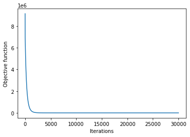

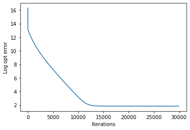

```python
plt.plot(OF_iteration[1:iter_count-1]),plt.ylabel('Objective function'),plt.xlabel('Iterations')
plt.show()

plt.plot(np.log(tolerance_iteration[1:iter_count-1])),plt.ylabel('Log opt error'),plt.xlabel('Iterations')
plt.show()
```

#### **Implementing Armijo Rule to adjust alpha for Gradient Descent**

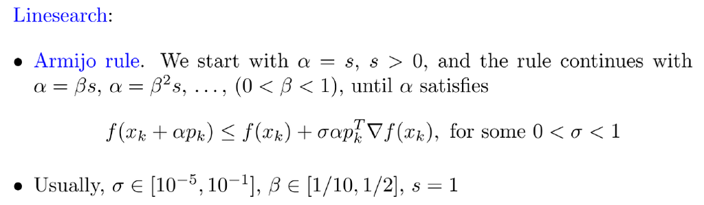

```python
def ArmijoLineSearch(beta, alpha, sigma, beta_decrease):

    while not ridge_reg((beta+alpha*descent_direction),X,Y) <= (ridge_reg(beta,X,Y) + sigma*alpha*np.dot(descent_direction,ridge_reg_der(beta,X,Y))):
        alpha = alpha*beta_decrease

    return alpha
```

```python
## empty lists to append inside each iteration value
OF_iteration = list()
tolerance_iteration = list()
alpha_iteration = list()

## Initial values for the variables
iterations = 30000 # maximum number of iterations
alpha = 1 ## initial
alpha_iteration.append(alpha)
precision = 0.00001 #This tells us when to stop the algorithm

beta = np.zeros(nvars+1) # xk # initial value for beta
previous_step_size = np.linalg.norm(ridge_reg_der(beta,X,Y),ord=2)

iter_count = 0
## process starts
time_start = time()
while (iter_count < iterations) and (previous_step_size > precision):
    descent_direction = -ridge_reg_der(beta,X,Y)
    #calculate new beta,f(x), ve gradient func

    alpha = ArmijoLineSearch(beta, alpha=alpha, sigma=0.1, beta_decrease=0.1)

    beta = beta + alpha*descent_direction

    previous_step_size = np.linalg.norm(ridge_reg_der(beta,X,Y),ord=2)
    iter_count = iter_count + 1 ## increasing iteration number

    ## appending to lists
    alpha_iteration.append(alpha)
    OF_iteration.append(ridge_reg(beta, X, Y))
    tolerance_iteration.append(previous_step_size)

## process ends
time_end = time()
## results
if iter_count==iterations: print('\nGradient descent does not converge.')
print('\nValues of the ridge regression coefficients - gradient method:')
print('Elapsed time = %8.5f' %(time_end- time_start))
print('\nNumber of iterations = %5.0f' %iter_count)
print('\nNumber of alpha = ' ,alpha_iteration[-1])
print('Objective function   = %11.5f' %OF_iteration[-1]) # the last, minimized OF.
print('Optimality tolerance = %11.5f' %previous_step_size)
beta_error = np.linalg.norm(np.transpose(beta_ridge_exact)-beta,ord=2)/np.linalg.norm(beta,ord=2)
print('\nBeta coefficient error = %10.5f' %beta_error)
```

```
Gradient descent does not converge.

Values of the ridge regression coefficients - gradient method:
Elapsed time = 14.40957

Number of iterations = 30000

Number of alpha =  1.0000000000000005e-07
Objective function   =  1844.49271
Optimality tolerance =     6.26020

Beta coefficient error =    0.02900
```

- As seen in the above results, even though, the alpha is smaller than the initial value, the algortihm does not converge with 30000 iterations.

##### Plotting Alpha evaluations through iterations

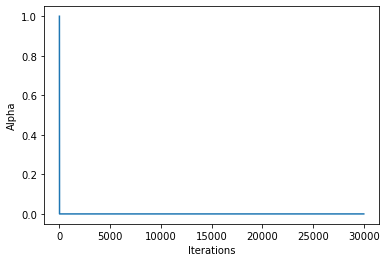

```python
plt.plot(alpha_iteration),plt.ylabel('Alpha'),plt.xlabel('Iterations')
plt.ticklabel_format(style='plain')    # to prevent scientific notation.
plt.show()
```

### 2. Newton's Method

#### Newton's Method Description and Formula

In this method, again, from an initial iterate $x_0$, descent direction which is $p_k=-(\nabla^2 f(x_k))^{-1} \nabla f(x_k)$ are computed whenever $\nabla^2 f(x_k)$ is nonsingular. In each iteration k, the movement of the method is following until it convergences to a local solution. $$x_{k+1} = x_k + \alpha_k\ p_k$$

```python
## empty lists to append inside each iteration value
OF_iteration = list()
tolerance_iteration = list()
alpha_iteration = list()

## Initial values for the variables
iterations = 30000 # maximum number of iterations
alpha = 0.01  ## initial
precision = 0.000001 #This tells us when to stop the algorithm

beta = np.zeros(nvars+1) # xk # initial value for beta
previous_step_size = np.linalg.norm(ridge_reg_der(beta,X,Y))

iter_count = 0
## process starts
time_start = time()
while (iter_count < iterations) and (previous_step_size > precision):

    gradient = ridge_reg_der(beta,X,Y)
    hess = ridge_reg_hess(beta,X,Y)
    descent_direction = -np.dot(np.linalg.inv(hess),gradient) # Descent direction

    #calculate new beta,f(x), ve gradient func
    #alpha = ArmijoLineSearch(beta, alpha=alpha, sigma=0.01, beta_decrease=0.1)

    beta = beta + alpha*descent_direction

    previous_step_size = np.linalg.norm(ridge_reg_der(beta,X,Y),ord=2)
    iter_count = iter_count + 1 ## increasing iteration number

    ## appending to lists
    alpha_iteration.append(alpha)
    OF_iteration.append(ridge_reg(beta, X, Y))
    tolerance_iteration.append(previous_step_size)

## process ends
time_end = time()
## results
if iter_count==iterations:
    print("\nNewton's method does not converge.")
else:
    print("\nNewton's method does converge.")
print('\nValues of the ridge regression coefficients - gradient method:')
print('Elapsed time = %8.5f' %(time_end- time_start))
print('\nNumber of iterations = %5.0f' %iter_count)
print('\nNumber of alpha = ' ,alpha_iteration[iter_count-1])
print('Objective function   = %11.5f' %OF_iteration[iter_count-1]) # the last, minimized OF.
print('Optimality tolerance = %11.5f' %previous_step_size)
beta_error = np.linalg.norm(np.transpose(beta_ridge_exact)-beta,ord=2)/np.linalg.norm(beta,ord=2)
print('\nBeta coefficient error = %10.5f' %beta_error)
```

```
Newton's method does converge.

Values of the ridge regression coefficients - gradient method:
Elapsed time =  3.12055

Number of iterations =  3092

Number of alpha =  0.01
Objective function   =  1841.74577
Optimality tolerance =     0.00000

Beta coefficient error =    0.00000
```

- As seen in the above results, Newton method does converge with 0.000001 precision value, 3092 iterations and 0.01 alpha value. The method reaches to almost zero error rate which is very successful.

#### Plotting Objective Function and Tolerance evaluations through iterations

As seen from graphs that OF has decreased sharply at the beginnning and the tolerance of each iteration has decreased continuesly until the end of iterations.

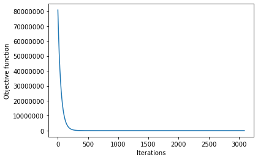

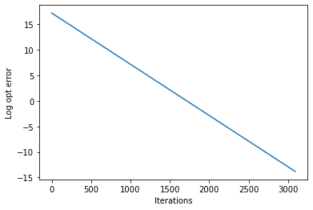

```python
# Plot results showing the evolution of the algorithm
plt.figure()
plt.plot(OF_iteration),plt.ylabel('Objective function'),plt.xlabel('Iterations')
plt.ticklabel_format(style='plain')    # to prevent scientific notation.
plt.show()

plt.plot(np.log(tolerance_iteration)),plt.ylabel('Log opt error'),plt.xlabel('Iterations')
plt.show()
```

#### Implementing Armijo Rule to adjust alpha for Newton method

```python
## empty lists to append inside each iteration value
OF_iteration = list()
tolerance_iteration = list()
alpha_iteration = list()

## Initial values for the variables
iterations = 10000 # maximum number of iterations
alpha = 1  ## initial
precision = 0.0001 #This tells us when to stop the algorithm

beta = np.zeros(nvars+1) # xk # initial value for beta
previous_step_size = np.linalg.norm(ridge_reg_der(beta,X,Y))

iter_count = 0
## process starts
time_start = time()
while (iter_count < iterations) and (previous_step_size > precision):

    gradient = ridge_reg_der(beta,X,Y)
    hess = ridge_reg_hess(beta,X,Y)
    descent_direction = -np.dot(np.linalg.inv(hess),gradient) # Descent direction

    #calculate new beta,f(x), ve gradient func
    alpha = ArmijoLineSearch(beta, alpha=alpha, sigma=0.01, beta_decrease=0.1)

    beta = beta + alpha*descent_direction

    previous_step_size = np.linalg.norm(ridge_reg_der(beta,X,Y),ord=2)
    iter_count = iter_count + 1 ## increasing iteration number

    ## appending to lists
    alpha_iteration.append(alpha)
    OF_iteration.append(ridge_reg(beta, X, Y))
    tolerance_iteration.append(previous_step_size)

## process ends
time_end = time()
## results
if iter_count==iterations:
    print("\nNewton's method does not converge.")
else:
    print("\nNewton's method does converge.")
print('\nValues of the ridge regression coefficients - gradient method:')
print('Elapsed time = %8.5f' %(time_end- time_start))
print('\nNumber of iterations = %5.0f' %iter_count)
print('\nNumber of alpha = ' ,alpha_iteration[-1])
print('Objective function   = %11.5f' %OF_iteration[-1]) # the last, minimized OF.
print('Optimality tolerance = %11.5f' %previous_step_size)
beta_error = np.linalg.norm(np.transpose(beta_ridge_exact)-beta,ord=2)/np.linalg.norm(beta,ord=2)
print('\nBeta coefficient error = %10.5f' %beta_error)
```

```
Newton's method does converge.

Values of the ridge regression coefficients - gradient method:
Elapsed time =  0.01787

Number of iterations =     9

Number of alpha =  1
Objective function   =  1841.74577
Optimality tolerance =     0.00006

Beta coefficient error =    0.00000
```

- From the above results, it can be interpretted that even though the armijo rule function has been started with 1 alpha value, the algorithm reached to optimality after only 9 iterations with the same alpha value. The error rate has been calculated very close to zero.

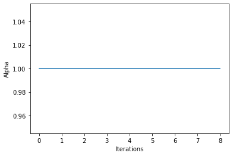

```python
plt.plot(alpha_iteration),plt.ylabel('Alpha'),plt.xlabel('Iterations')
plt.ticklabel_format(style='plain')    # to prevent scientific notation.
plt.show()
```

### 3. Quasi-Newton method

#### Quasi-Newton method Description and Formula

Quasi-Newton Formula

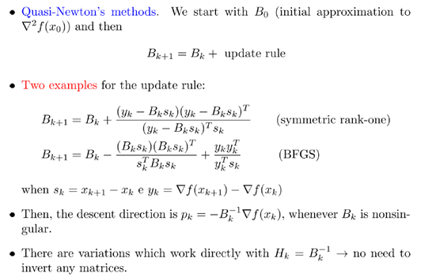

In this step, BFGS update rule has been examined.

```python
## empty lists to append inside each iteration value
OF_iteration = list()
tolerance_iteration = list()
alpha_iteration = list()

## Initial values for the variables
iterations = 10000 # maximum number of iterations
alpha = 0.1  ## initial
precision = 0.0001 #This tells us when to stop the algorithm

## Initial parameters
beta = np.zeros(nvars+1) # xk # initial value for beta
gradient = ridge_reg_der(beta,X,Y)
Bk = ridge_reg_hess(beta,X,Y) ## initial approximation to hessian matrix.
previous_step_size = np.linalg.norm(gradient)

iter_count = 0
## process starts
time_start = time()

while (iter_count < iterations) and (previous_step_size > precision):

    descent_direction = -np.dot(np.linalg.inv(Bk),gradient)

    #Compute the step length lambda with a line search procedure that satisfies Wolfe conditions.
    alpha = ArmijoLineSearch(beta, alpha=alpha, sigma=0.01, beta_decrease=0.1)

    beta_1 = beta + alpha*descent_direction

    sk = beta_1-beta
    yk = ridge_reg_der(beta_1,X,Y) - ridge_reg_der(beta,X,Y)

    beta = beta_1

    eq1 = -np.dot(np.dot(Bk, sk),np.dot(Bk, sk).T)
    eq_denom1 = np.dot(sk.T, Bk, sk)
    divide1 = np.divide(eq1,eq_denom1, where=eq_denom1!=0) ## denominator cannot be zero.

    eq2 = np.dot(yk , yk.T)
    eq_denom2 = np.dot(yk.T , sk)
    divide2 = np.divide(eq2,eq_denom2, where=eq_denom2!=0) ## denominator cannot be zero.
    Bk = Bk + divide1 + divide2

    ##iterate
    previous_step_size = np.linalg.norm(ridge_reg_der(beta,X,Y),ord=2)
    iter_count = iter_count + 1 ## increasing iteration number

    ## appending to lists
    OF_iteration.append(ridge_reg(beta, X, Y))
    alpha_iteration.append(alpha)
    tolerance_iteration.append(previous_step_size)

## process ends
time_end = time()
## results
print('\nValues of the ridge regression coefficients - quasi-newton method:')
print('Elapsed time = %8.5f' %(time_end- time_start))
print('\nNumber of iterations = %5.0f' %iter_count)
print('\nNumber of alpha = ' ,alpha_iteration[-1])
print('Objective function   = %11.5f' %OF_iteration[-1]) # the last, minimized OF.
print('Optimality tolerance = %11.5f' %previous_step_size)
beta_error = np.linalg.norm(np.transpose(beta_ridge_exact)-beta,ord=2)/np.linalg.norm(beta,ord=2)
print('\nBeta coefficient error = %10.5f' %beta_error)
```

```
Values of the ridge regression coefficients - quasi-newton method:
Elapsed time = 15.21355

Number of iterations = 10000

Number of alpha =  1.000000000000001e-17
Objective function   =  2300.58365
Optimality tolerance =   522.20124

Beta coefficient error =    0.35416
```

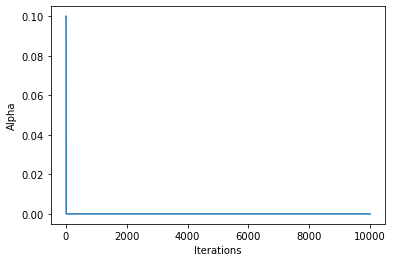

```python
# Plot results showing the evolution of the algorithm
plt.plot(alpha_iteration),plt.ylabel('Alpha'),plt.xlabel('Iterations')
plt.show()
```

## d) Estimating the value of the regression coefficients by implementing:

### **1.Coordinate gradient method**

Coordinated Descent (CD) Formula

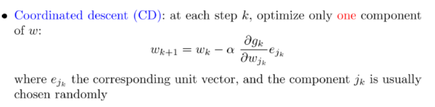

In this step, the coordinated descent function has been created by using the above formula.

```python
## Initial values for the variables and data containers
iterations = 4000 # maximum number of iterations
OF_iteration = list()

## initializing w with zeros
w_beta = np.zeros(nvars+1) # initial value for beta
alpha = 0.0001

## process starts
time_start = time()
for k in range(iterations):
    gradient = ridge_reg_der(w_beta,X,Y)
    for j in range(len(w_beta)): #nvars+1 = len(w_beta)

        unit_vector_jk = gradient[j] / np.linalg.norm(gradient) ##unit vector e_jk
        descent_direction = gradient/gradient[j]
        w_beta = w_beta - alpha*descent_direction*unit_vector_jk

        OF_iteration.append(ridge_reg(w_beta, X, Y)) ## calculating the OF (cost) of ridge regression with ridge_reg function

## process ends
time_end = time()

## results
print('\nValues of the ridge regression coefficients - coordinated descent method:')
print('Elapsed time = %8.5f' %(time_end- time_start))
print('Objective function   = %11.5f' %OF_iteration[-1]) # the last, minimized OF.

beta_error = np.linalg.norm(np.transpose(beta_ridge_exact)-w_beta,ord=2)/np.linalg.norm(w_beta,ord=2)
print('\nBeta coefficient error = %10.5f' %beta_error)

## estimated betas
print('beta %-9s %7.3f' %('intercept',w_beta[0]))
col_list = ['X' + str(x) for x in range(0,nvars+1)]
for i in np.arange(1,nvars+1):
    print('beta %-9s %7.3f' %(col_list[i],w_beta[i]))
```

```
Values of the ridge regression coefficients - coordinated descent method:
Elapsed time = 60.83374
Objective function   =  1972.13662

Beta coefficient error =    0.02960
beta intercept  -0.095
beta X1          0.984
beta X2         -3.976
beta X3          0.982
beta X4         -2.992
beta X5          2.986
beta X6          1.978
beta X7          2.010
beta X8          2.991
beta X9         -5.005
beta X10         0.994
beta X11        -0.992
beta X12        -1.010
beta X13         0.003
beta X14         1.971
beta X15         1.992
beta X16         3.989
beta X17        -1.990
beta X18         3.979
beta X19        -4.002
beta X20        -3.005
beta X21         1.998
beta X22         0.964
beta X23         2.013
beta X24        -0.019
beta X25        -2.016
beta X26        -1.009
beta X27        -2.975
beta X28        -0.975
beta X29         2.993
beta X30        -4.005
beta X31         2.011
beta X32        -3.021
beta X33        -1.972
beta X34        -1.013
```

[output cut: 71 more lines]

```
beta X106        2.010
beta X107       -0.981
beta X108        4.000
beta X109       -1.019
beta X110        3.977
beta X111        0.982
beta X112       -0.032
beta X113       -2.020
beta X114       -5.014
beta X115       -3.979
beta X116       -0.005
beta X117        1.992
beta X118        2.021
beta X119        1.987
beta X120       -4.013
```

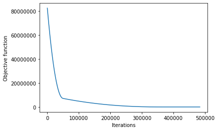

```python
# Plot results showing the evolution of the algorithm
plt.figure()
plt.plot(OF_iteration),plt.ylabel('Objective function'),plt.xlabel('Iterations')
plt.ticklabel_format(style='plain')    # to prevent scientific notation.
plt.show()
```

### **2.Mini-batch gradient method**

In this step the effects of the mini-batch size in algorithm performance (number of iterations and computational time needed to reach a pre-specified tolerance limit) has been studied.

Mini-batch gradient descent formula

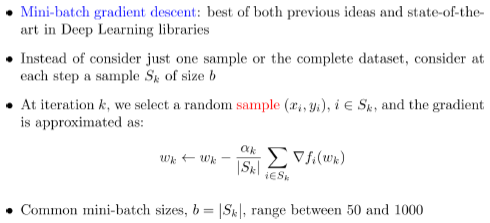

First, "mini_batch" function has been created in order to create batch samples in X and Y.

```python
# function to create a list containing mini-batches
## normally mini-batch sizes range between 50 and 1000.
def mini_batch(batch_size, X, Y):
    mini_batches = []
    data = np.concatenate([X, Y],axis=1)
    np.random.shuffle(data)
    n_minibatches = data.shape[0] // batch_size ##20

    for i in range(n_minibatches):
        mini_batch = data[i * batch_size : (i + 1)*batch_size, :]
        X_mini = mini_batch[:, :-1]
        Y_mini = mini_batch[:, -1].reshape((-1, 1))
        mini_batches.append((X_mini, Y_mini))
    if data.shape[0] % batch_size != 0:
        mini_batch = data[i * batch_size:data.shape[0]]
        X_mini = mini_batch[:, :-1]
        Y_mini = mini_batch[:, -1].reshape((-1, 1))
        mini_batches.append((X_mini, Y_mini))

    return mini_batches
```

In this part, 5 different batch size has been tried. (30,50,300,500,1000).

```python
print('\nRidge regression coefficients - mini-batch descent method:')

batch_sizes = [30,50,300,500,1000]
for batch_size in batch_sizes:
    ## empty lists to append inside each iteration value
    OF_iteration = list()
    tolerance_iteration = list()
    ## Initial values for the variables
    iterations = 4000 # maximum number of iterations
    alpha = 0.0001  ## initial
    beta = np.zeros(nvars+1)
    previous_step_size = np.linalg.norm(ridge_reg_der(beta,X,Y))
    precision = 0.000001 #This tells us when to stop the algorithm

    iter_count = 0
    ## process starts
    time_start = time()
    while (iter_count < iterations) and (previous_step_size > precision):
        mini_batches = mini_batch(batch_size, X, Y)
        for batch in mini_batches:
            X_mini, Y_mini = batch
            beta = beta - (alpha/ batch_size) * ridge_reg_der(beta, X_mini, Y_mini)

            OF_iteration.append(ridge_reg(beta, X_mini, Y_mini))
            previous_step_size = np.linalg.norm(ridge_reg_der(beta,X,Y),ord=2)
            tolerance_iteration.append(previous_step_size)
        iter_count = iter_count + 1 ## increasing iteration number

    ## process ends
    time_end = time()

    ## results
    print('\nBatch_size: ', batch_size)
    print('Elapsed time = %8.5f' %(time_end- time_start))
    print('Objective function   = %11.5f' %OF_iteration[-1]) # the last, minimized OF.
    print('Number of iterations = %5.0f' %iter_count)
    print('Optimality tolerance = %11.5f' %previous_step_size)
    beta_error = np.linalg.norm(np.transpose(beta_ridge_exact)-beta,ord=2)/np.linalg.norm(beta,ord=2)
    print('Beta coefficient error = %10.5f' %beta_error)
```

```
Ridge regression coefficients - mini-batch descent method:

Batch_size:  30
Elapsed time = 34.39688
Objective function   =   949.64590
Number of iterations =  4000
Optimality tolerance = 25770.26508
Beta coefficient error =    0.02828

Batch_size:  50
Elapsed time = 27.62812
Objective function   =   959.58907
Number of iterations =  4000
Optimality tolerance = 20420.47121
Beta coefficient error =    0.02841

Batch_size:  300
Elapsed time = 16.48434
Objective function   =  1301.03573
Number of iterations =  4000
Optimality tolerance = 11953.76960
Beta coefficient error =    0.02927

Batch_size:  500
Elapsed time = 13.11485
Objective function   =  1377.79658
Number of iterations =  4000
Optimality tolerance =  1441.89442
Beta coefficient error =    0.02947

Batch_size:  1000
Elapsed time = 13.26293
Objective function   =  2487.99088
Number of iterations =  4000
Optimality tolerance =  3384.00711
Beta coefficient error =    0.03238
```

### **3. Mini-batch gradient with momentum**

In this step, the momentum(v) has been implemented to the previously obtained mini-batch algortihm. Here, apart from alpha parameter (learning rate), there is also beta parameter which is similar to acceleration in mechanics.

```python
beta_k = 0.95
v = np.zeros(nvars+1)

## empty lists to append inside each iteration value
OF_iteration = list()
tolerance_iteration = list()
## Initial values for the variables
iterations = 10000 # maximum number of iterations
alpha = 0.000001  ## initial
beta = np.zeros(nvars+1)
previous_step_size = np.linalg.norm(ridge_reg_der(beta,X,Y))
precision = 0.000001 #This tells us when to stop the algorithm
batch_size = 50

iter_count = 0
## process starts
time_start = time()
while (iter_count < iterations) and (previous_step_size > precision):
    mini_batches = mini_batch(batch_size, X, Y)
    for batch in mini_batches:
        X_mini, Y_mini = batch
        # momentum
        v = beta_k * v + (1-beta_k) * ridge_reg_der(beta, X_mini, Y_mini)
        beta = beta - alpha* v

        OF_iteration.append(ridge_reg(beta, X_mini, Y_mini))
        previous_step_size = np.linalg.norm(ridge_reg_der(beta,X,Y),ord=2)
        tolerance_iteration.append(previous_step_size)
    iter_count = iter_count + 1 ## increasing iteration number

## process ends
time_end = time()

## results
print('\nBatch_size: ', batch_size)
print('Elapsed time = %8.5f' %(time_end- time_start))
print('Objective function   = %11.5f' %OF_iteration[-1]) # the last, minimized OF.
print('Number of iterations = %5.0f' %iter_count)
print('Optimality tolerance = %11.5f' %previous_step_size)
beta_error = np.linalg.norm(np.transpose(beta_ridge_exact)-beta,ord=2)/np.linalg.norm(beta,ord=2)
print('Beta coefficient error = %10.5f' %beta_error)
```

```
Batch_size:  50
Elapsed time = 107.31314
Objective function   =   957.94615
Number of iterations = 10000
Optimality tolerance =  1615.12554
Beta coefficient error =    0.02812
```

## f) Consider the constrained problem:

$$ \min_{\beta} ||y-X\beta||^2_2$$$$ st: \sum_{i=1}^{K} \beta_{i} = 1 $$

Estimate the optimal value of the regression coefficients in (1) by implementing a penalization algorithm

```python
# penalization function
def penalization(beta_pn,X,Y):
    rho = 1
    beta_pn = np.matrix(beta_pn)
    z = Y - np.dot(X,beta_pn.T)
    val_f = np.dot(z.T,z) + 1*np.dot(beta_pn - 1,(beta_pn - 1).T)
    val_ff = np.squeeze(np.asarray(val_f))
    return val_ff # OF

# gradient function
def penalization_der(beta_pn,X,Y):
    beta_pn = np.matrix(beta_pn)
    gradient = -2*np.dot((Y-np.dot(X,(beta_pn).T)).T,X) + 2 * 1 * beta_pn -2
    aa = np.squeeze(np.asarray(gradient))
    return aa
from scipy.optimize import minimize

beta_ls = np.zeros(nvars+1)

time_start = time()
res = minimize(penalization, beta_ls, args=(X, Y),  jac=penalization_der, hess=None, method='BFGS', options={'disp': True})
time_elapsed = (time() - time_start)

# Print results
print('\nValues of the least squares coefficients obtained with Nelder-Mead:')
for i in range(nvars+1):
    print('beta %3d %7.3f' %(i,res.x[i]))
```

```
Optimization terminated successfully.
         Current function value: 2072.526910
         Iterations: 141
         Function evaluations: 257
         Gradient evaluations: 257

Values of the least squares coefficients obtained with Nelder-Mead:
beta   0  -0.763
beta   1   1.000
beta   2  -3.980
beta   3   0.986
beta   4  -2.995
beta   5   3.000
beta   6   1.982
beta   7   2.011
beta   8   2.995
beta   9  -5.005
beta  10   0.993
beta  11  -0.999
beta  12  -1.011
beta  13   0.008
beta  14   1.973
beta  15   1.990
beta  16   3.997
beta  17  -1.983
beta  18   3.982
beta  19  -3.999
beta  20  -3.008
beta  21   1.997
beta  22   0.980
beta  23   2.016
beta  24  -0.018
beta  25  -2.013
beta  26  -0.997
beta  27  -2.978
beta  28  -0.974
beta  29   2.999
beta  30  -4.007
beta  31   2.017
beta  32  -3.028
```

[output cut: 73 more lines]

```
beta 106   2.012
beta 107  -0.990
beta 108   4.017
beta 109  -1.013
beta 110   3.981
beta 111   0.985
beta 112  -0.032
beta 113  -2.013
beta 114  -5.008
beta 115  -3.991
beta 116   0.001
beta 117   1.995
beta 118   2.009
beta 119   1.988
beta 120  -4.009
```